# 데이터 탐색 및 전처리 프로젝트 (EDA)

# tips data

### 이한솔, 장보윤, 현승우

tips 데이터 불러오기  
마지막 데이터 5개 탐색

```python
tips = sns.load_dataset("tips")
tips.tail(5)
```

|  | total_bill | tip | sex | smoker | day | time | size |
| --- | --- | --- | --- | --- | --- | --- | --- |
| 239 | 29.03 | 5.92 | Male | No | Sat | Dinner | 3 |
| 240 | 27.18 | 2.00 | Female | Yes | Sat | Dinner | 2 |
| 241 | 22.67 | 2.00 | Male | Yes | Sat | Dinner | 2 |
| 242 | 17.82 | 1.75 | Male | No | Sat | Dinner | 2 |
| 243 | 18.78 | 3.00 | Female | No | Thur | Dinner | 2 |

244개의 관측치와 7개의 변수로 이루어진 데이터 프레임

```python
tips.shape
```

```
(244, 7)
```

# 어떤 손님이 팁을 더 많이 줄까?

### 1. 잔돈을 많이 거슬러 받은 손님이 팁을 많이 줄 것이다.

### 2. 평균 인당 식사비용(Total_bill / Size)이 높으면 팁을 많이 줄 것이다.

### 3. 금, 토 저녁에 식사하는 손님이 팁을 많이 줄 것이다.

### 4. 주말에는 손님이 많아, 서비스 질이 낮아지므로 팁을 적게 줄 것이다.

### 5. 여성 웨이터가 친절해서 팁을 더 많이 받을 것이다.

### 6. 흡연자 손님이 팁을 더 많이 줄 것이다.

## 가설 1: 잔돈을 많이 거슬러 받은 손님이 팁을 많이 줄 것이다.

- **필요변수 : total_bill, tip**

tip에 관한 히스토그램 시각화

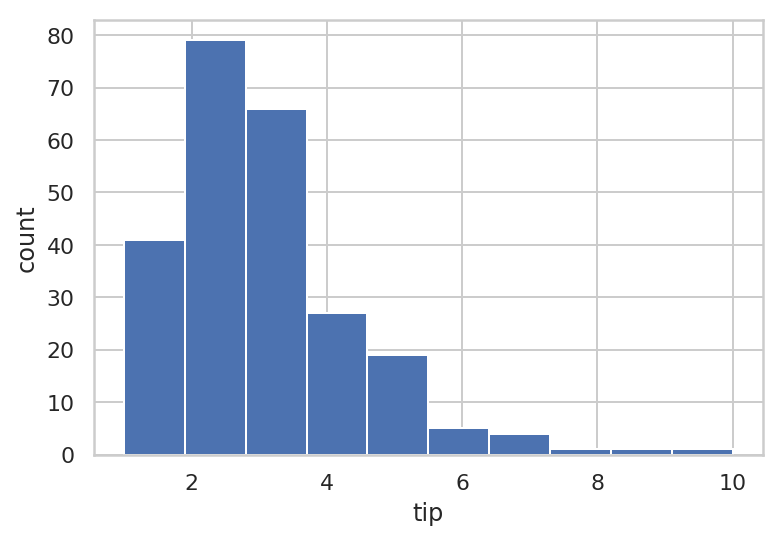

```python
plt.hist(tips.tip)
plt.xlabel("tip")
plt.ylabel("count")
plt.show()
```

total_bill에 관한 히스토그램 시각화

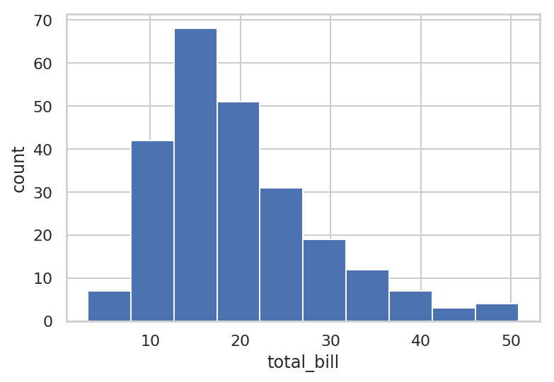

```python
plt.hist(tips.total_bill)
plt.xlabel("total_bill")
plt.ylabel("count")
plt.show()
```

change 거스름돈 데이터 생성  
5$ 단위의 지폐를 냈다고 가정하고 거스름돈 계산

```python
changes = pd.DataFrame(tips, columns= {"total_bill", "tip"})
pay_unit = 5 #올림단위
changes["change"] = changes["total_bill"].apply(lambda x : np.ceil(x/pay_unit)*pay_unit - x) #거스름돈($5 단위로 계산시)
changes.tail()
```

|  | tip | total_bill | change |
| --- | --- | --- | --- |
| 239 | 5.92 | 29.03 | 0.97 |
| 240 | 2.00 | 27.18 | 2.82 |
| 241 | 2.00 | 22.67 | 2.33 |
| 242 | 1.75 | 17.82 | 2.18 |
| 243 | 3.00 | 18.78 | 1.22 |

change와 tip의 상관계수

```python
changes[["tip","change"]].corr()
```

|  | tip | change |
| --- | --- | --- |
| tip | 1.000000 | -0.087514 |
| change | -0.087514 | 1.000000 |

change와 tip: scatter plot + 회귀선

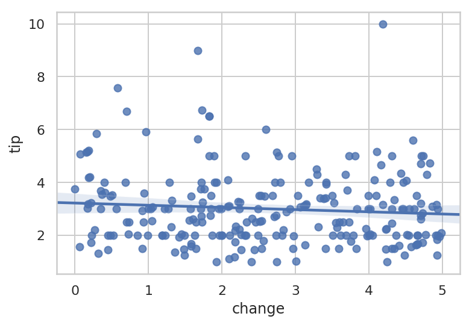

```python
sns.regplot(x="change", y="tip", data=tip_change)
plt.show()
```

## 분명 많은 사람들이 카드를 이용했을 것이므로, 현금으로 냈다는 가정에 문제가 있음

## 잔돈과 팁은 상관이 없다.

## 가설 2: 평균 인당 식사비용 (Total_bill / Size)이 높으면 팁을 많이 줄 것이다.

- **필요변수 : total_bill. size**

인당 식사비(total_bill / size)가 높을수록 tip을 많이 냈을 것이다.

```python
tip_billsize = pd.DataFrame(tips, columns={"tip" ,"size", "total_bill"})
tip_billsize["bill/size"] = tip_billsize["total_bill"]/tips["size"] # 인당 식사비용 컬럼화
```

```python
tip_billsize["bill/size"] = round(tip_billsize["bill/size"], 2) # bill/size 를 소수점 둘째 자리까지 변환
tip_billsize.tail()
```

|  | size | total_bill | tip | bill/size |
| --- | --- | --- | --- | --- |
| 239 | 3 | 29.03 | 5.92 | 9.68 |
| 240 | 2 | 27.18 | 2.00 | 13.59 |
| 241 | 2 | 22.67 | 2.00 | 11.34 |
| 242 | 2 | 17.82 | 1.75 | 8.91 |
| 243 | 2 | 18.78 | 3.00 | 9.39 |

tip과 bill/size간의 상관 계수

```python
tip_billsize[["tip", "bill/size"]].corr()
```

|  | tip | bill/size |
| --- | --- | --- |
| tip | 1.000000 | 0.347405 |
| bill/size | 0.347405 | 1.000000 |

인당식사비와 시각화

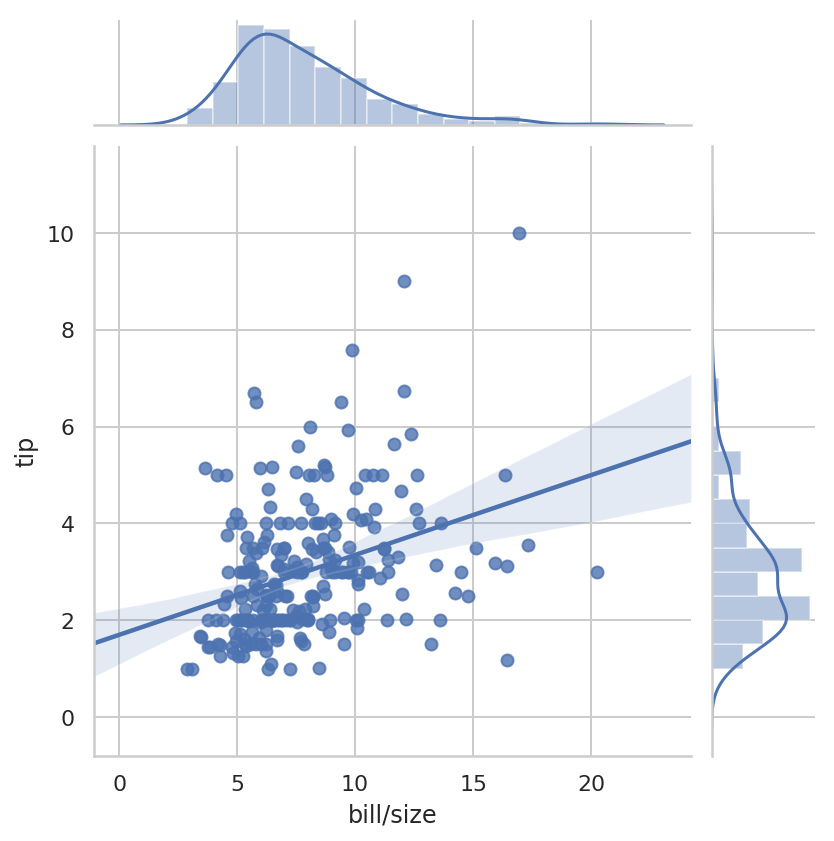

```python
sns.jointplot("bill/size", "tip", data=tip_billsize, kind='reg')
plt.show()
```

sex에 따른 total_bill/size 분포 히트맵

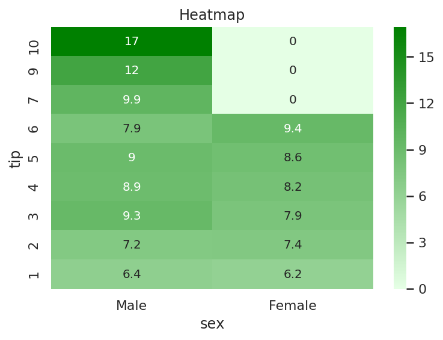

```python
tb_size = pd.DataFrame(tips, columns= {"tip", "total_bill", "size"})
tb_size["total_bill/size"] = tb_size["total_bill"] / tb_size["size"]

ts_sex_h = pd.DataFrame(tips, columns= {"sex", "tip"})
ts_sex_h["t/s"] = tb_size["total_bill/size"]
ts_sex_h["tip"] = ts_sex_h["tip"].apply(lambda x : int(x) if x % 1 == 0.00 else int(round(x -.5))) #팁 소수점 버림
ts_sex_h = ts_sex_h.pivot_table("t/s", ["tip"], ["sex"], aggfunc=np.mean, dropna=False, fill_value = 0)[::-1]

sns.heatmap(ts_sex_h, cmap=sns.light_palette("green", as_cmap=True), annot=True)
plt.title("Heatmap")
plt.show()
```

smoker에 따른 total_bill/size 분포 히트맵

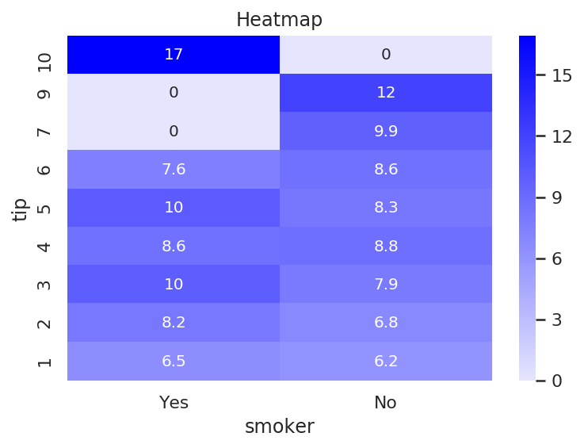

```python
ts_smk_h = pd.DataFrame(tips, columns= {"smoker", "tip"})
ts_smk_h["t/s"] = tb_size["total_bill/size"]
ts_smk_h["tip"] = ts_smk_h["tip"].apply(lambda x : int(x) if x % 1 == 0.00 else int(round(x -.5))) #팁 소수점 버림
ts_smk_h = ts_smk_h.pivot_table("t/s", ["tip"], ["smoker"], aggfunc=np.mean, dropna=False, fill_value = 0)[::-1]

sns.heatmap(ts_smk_h, cmap=sns.light_palette("blue", as_cmap=True), annot=True)
plt.title("Heatmap")
plt.show()
```

day에 따른 total_bill/size 분포 히트맵

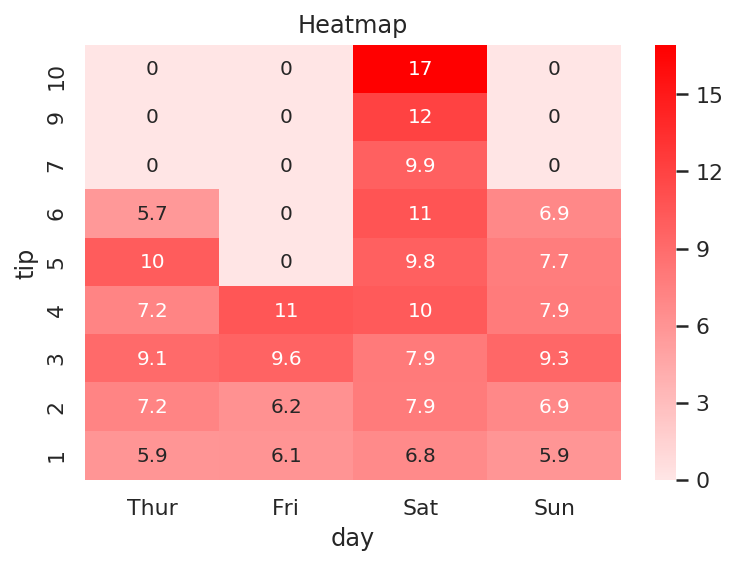

```python
ts_day_h = pd.DataFrame(tips, columns= {"day", "tip"})
ts_day_h["t/s"] = tb_size["total_bill/size"]
ts_day_h["tip"] = ts_day_h["tip"].apply(lambda x : int(x) if x % 1 == 0.00 else int(round(x -.5))) #팁 소수점 버림
ts_day_h = ts_day_h.pivot_table("t/s", ["tip"], ["day"], aggfunc=np.mean, dropna=False, fill_value = 0)[::-1]

sns.heatmap(ts_day_h, cmap=sns.light_palette("red", as_cmap=True), annot=True)
plt.title("Heatmap")
plt.show()
```

time에 따른 total_bill/size 분포 히트맵

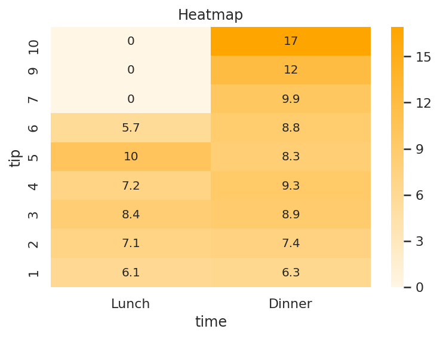

```python
ts_time_h = pd.DataFrame(tips, columns= {"time", "tip"})
ts_time_h["t/s"] = tb_size["total_bill/size"]
ts_time_h["tip"] = ts_time_h["tip"].apply(lambda x : int(x) if x % 1 == 0.00 else int(round(x -.5))) #팁 소수점 버림
ts_time_h = ts_time_h.pivot_table("t/s", ["tip"], ["time"], aggfunc=np.mean, dropna=False, fill_value = 0)[::-1]

sns.heatmap(ts_time_h, cmap=sns.light_palette("orange", as_cmap=True), annot=True)
plt.title("Heatmap")
plt.show()
```

## 평균 인당 식사비용과 팁은 상관관계가 있다.

## 가설 3: 금, 토 저녁에 식사하는 손님이 팁을 많이 줄 것이다.

- **필요변수 : day, time, tip**

## 가설 4: 주말에는 손님이 많아, 서비스 질이 낮아지므로 팁을 적게 줄 것이다.

- **필요변수 : day, tip**

시간과 팁의 관계

```python
tip_avg = tips["tip"].mean()
tip_avg = round(tip_avg, 5)
tip_time = pd.DataFrame(tips, columns = {"time", "tip"})
tip_time_over_avg = tip_time[tip_time["tip"] > tip_avg] # 평균 이상의 값들만 정렬
tip_time_over_avg = tip_time_over_avg.groupby("time").size().reset_index(name="counts") # 카운트값
tip_time_over_avg["percent"] = tip_time_over_avg["counts"].values / tip_time_cnt["dayCnt"].values  #백분율 도출
tip_time_over_avg
```

|  | time | counts | percent |
| --- | --- | --- | --- |
| 0 | Lunch | 23 | 0.338235 |
| 1 | Dinner | 98 | 0.556818 |

해석: 저녁에 온 손님 중 55% 이상이 평균보다 팁을 많이 냈다.

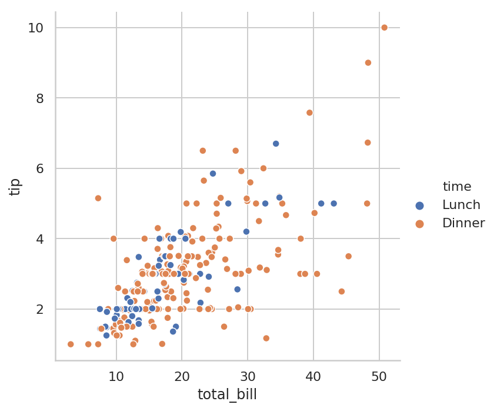

```python
sns.relplot(x="total_bill", y="tip", hue="time", data=tips)
plt.show()
```

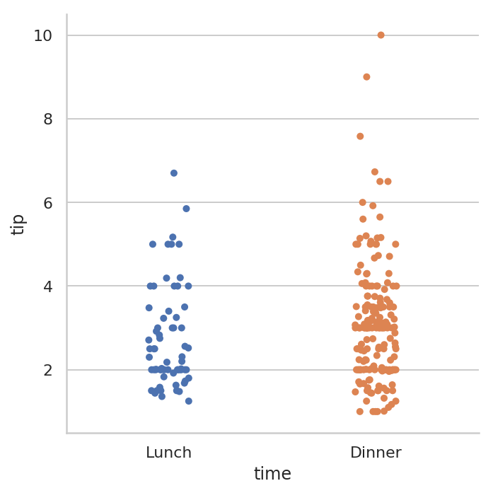

```python
sns.catplot(x="time", y="tip", data=tips)
plt.show()
```

Lunch와 Dinner의 tip에 대한 평균의 차이를 알아보는 ttest

```python
from scipy import stats
lun = tips[tips.time == "Lunch"].tip
din = tips[tips.time == "Dinner"].tip
sp.stats.levene(lun, din) # 등분산성 만족 X
```

```
LeveneResult(statistic=0.88098601335503, pvalue=0.3488676006910484)
```

```python
result = stats.ttest_ind(lun, din, equal_var = False)
print("t검정 통계량: %.3f, pvalue=%.3f"%(result))
```

```
t검정 통계량: -2.059, pvalue=0.041
```

Lunch와 Dinner 팁 평균에 차이가 있다.

```python
tip_day_over_avg["percent"] = tip_day_over_avg["counts"].values / tip_day_cnt["dayCnt"].values #백분율 도출
tip_day_over_avg
```

|  | day | counts | percent |
| --- | --- | --- | --- |
| 0 | Thur | 22 | 0.354839 |
| 1 | Fri | 10 | 0.526316 |
| 2 | Sat | 42 | 0.482759 |
| 3 | Sun | 47 | 0.618421 |

해석: 일요일에 온 손님 중 61% 이상이 평균보다 팁을 많이 냈다.

요일별 팁에 대한 box plot

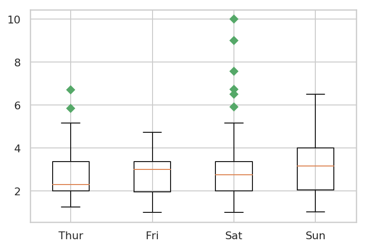

```python
thur = tips["tip"][tips.day == "Thur"]
fri = tips["tip"][tips.day == "Fri"]
sat = tips["tip"][tips.day == "Sat"]
sun = tips["tip"][tips.day == "Sun"]
plot_data = [thur, fri, sat, sun]
plt.boxplot(plot_data, labels = ["Thur", "Fri", "Sat", "Sun"], notch = 0, sym = 'gD')
plt.show()
```

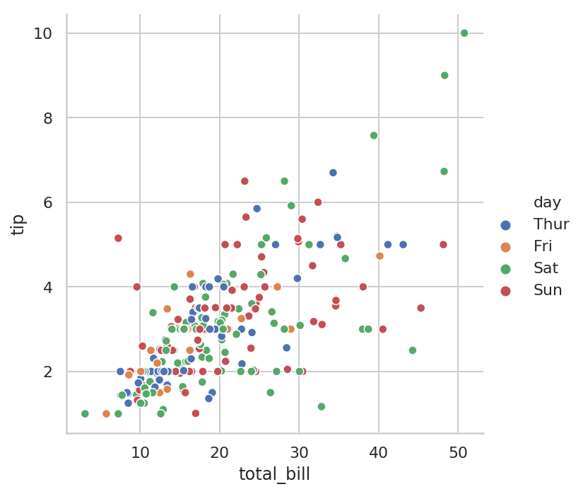

```python
sns.relplot(x="total_bill", y="tip", hue="day", data=tips)
plt.show()
```

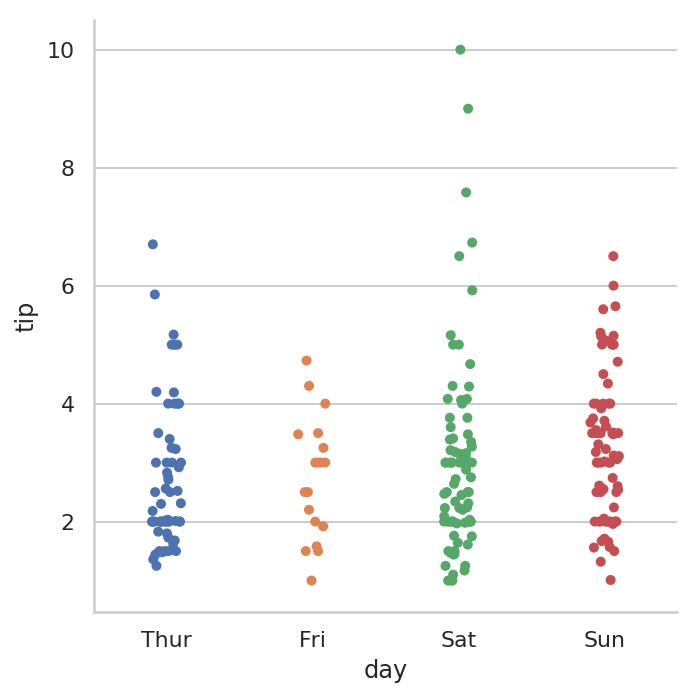

```python
sns.catplot(x="day", y="tip", data=tips)
plt.show()
```

```python
tips.pivot_table(index = "day", columns = "time", values = "tip", aggfunc=[len, np.mean], fill_value = 0)
```

| time day | len Dinner | len Lunch | mean Dinner | mean Lunch |
| --- | --- | --- | --- | --- |
| Sun | 76 | 0 | 3.255132 | 0.000000 |
| Sat | 87 | 0 | 2.993103 | 0.000000 |
| Thur | 1 | 61 | 3.000000 | 2.767705 |
| Fri | 12 | 7 | 2.940000 | 2.382857 |

Friday의 관측치 수가 30 미만이므로 정규성 검정을 따로 실시해야한다.  
정규성 검정: Kolmogorov-Smirnov 검정  
등분산성 검정: scipy.stats.levene  
Friday가 정규성이 없으므로 t test 가 아닌 mann - whitney 검정을 해야한다.

```python
from scipy import stats
Fri = tips[tips.day == "Fri"].tip
Sun = tips[tips.day == "Sun"].tip

sp.stats.ks_2samp(Fri, Sun) # 정규성 검정 X

sp.stats.levene(Fri, Sun) # 등분산성 검정 X
```

```
LeveneResult(statistic=0.8528084349901766, pvalue=0.3581488604338977)
```

```python
stats.mannwhitneyu(Fri, Sun)
```

```
MannwhitneyuResult(statistic=533.5, pvalue=0.03987052356524529)
```

Friday와 Sunday간 팁 평균의 차이가 있다.

## 점심과 저녁 시간 대에 팁 평균에 차이가 있고

## 금요일과 일요일 팁 평균에도 차이가 있다.

## 시간과 요일은 팁에 영향을 미친다.

## 가설 5: 여성 웨이터가 친절해서 팁을 더 많이 받을 것이다.

- **필요변수 : sex, tip**

```python
sex[["sex", "tip", "count"]]
sex.index = ["Male", "Female"]
sex
sex[["tip", "count"]]
```

|  | tip | count |
| --- | --- | --- |
| Male | 3.089618 | 157 |
| Female | 2.833448 | 87 |

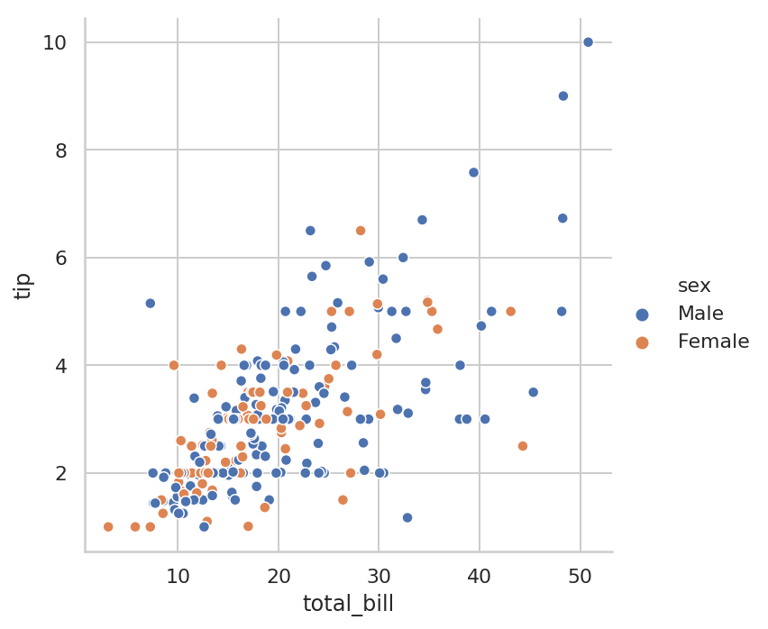

```python
sns.relplot(x="total_bill", y="tip", hue="sex", data=tips)
plt.show()
```

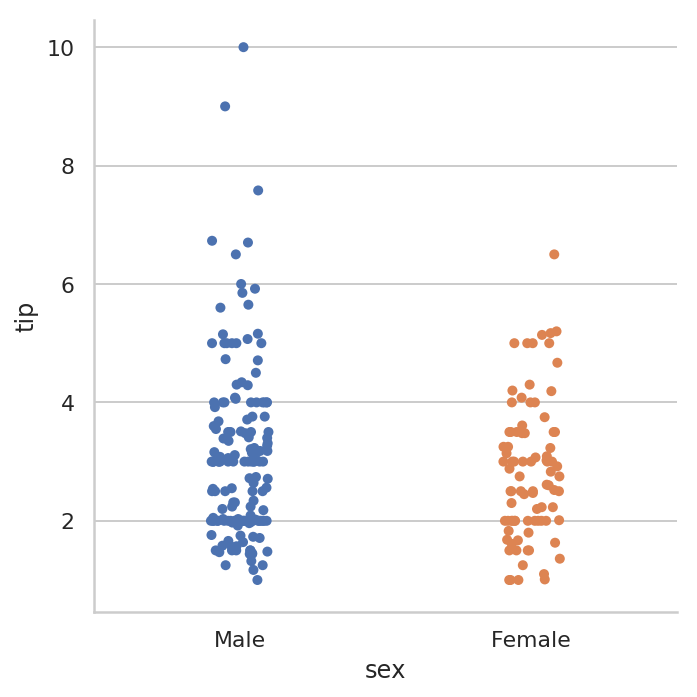

```python
sns.catplot(x="sex", y="tip", data=tips)
plt.show()
```

t test

```python
# 평균 차이를 알아보는 ttest 유의수준 5% 이상이면 귀무가설 기각 불가 (두 집단 간 평균차이가 없다.)
from scipy import stats
male = tips[tips.sex == "Male"].tip
female = tips[tips.sex == "Female"].tip
sp.stats.levene(male, female) # 등분산성 X
```

```
LeveneResult(statistic=1.9909710178779405, pvalue=0.1595236359896614)
```

```python
result = stats.ttest_ind(male, female, equal_var = False)
print("t검정 통계량: {0[0]:.3f}, pvalue={0[1]:.3f}".format(result))
```

```
t검정 통계량: 1.490, pvalue=0.138
```

## t test 결과로 남자웨이터와 여자웨이터가 받는 팁 평균에 차이가 없다.

## 가설 6: 흡연자 손님이 팁을 더 많이 줄 것이다.

- **필요변수 : smoker, tip**

```python
smoke["tip"] = smoke_mean.tip.values
smoke.index = ["smoker", "nonsmoker"]
smoke[["tip", "count"]]
```

|  | tip | count |
| --- | --- | --- |
| smoker | 3.008710 | 93 |
| nonsmoker | 2.991854 | 151 |

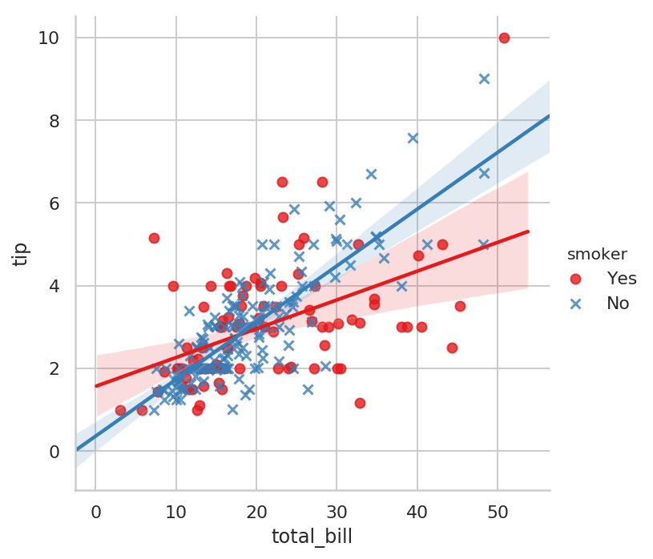

```python
sns.lmplot(x = "total_bill", y = "tip", hue = "smoker", data = tips, markers = ["o", "x"], palette="Set1")
plt.show()
```

t test

```python
# ttest : 두 집단 간의 차이가 없다.
from scipy import stats
smo = tips[tips.smoker == "Yes"].tip
nonsmo = tips[tips.smoker == "No"].tip
sp.stats.levene(smo, nonsmo) # 등분산성 X
```

```
LeveneResult(statistic=0.02051159105706963, pvalue=0.8862366542563406)
```

```python
result = stats.ttest_ind(smo, nonsmo, equal_var = False)
print("t검정 통계량: %.3f, pvalue=%.3f"%(result))
```

```
t검정 통계량: 0.092, pvalue=0.927
```

## 흡연자와 비흡연자가 주는 팁 평균에 차이가 없다.

# 회귀분석

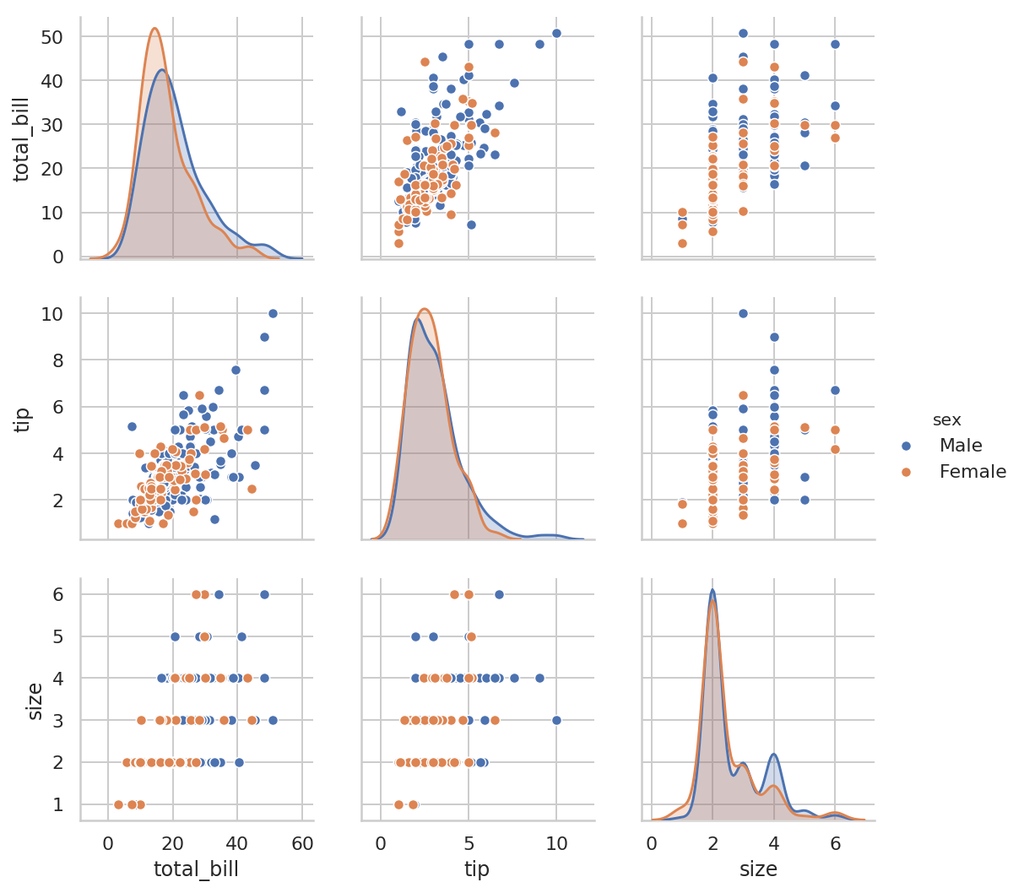

```python
sns.pairplot(tips, hue = "sex")
plt.show()
```

```python
from statsmodels.formula.api import ols

fit = ols('tip ~ total_bill + C(size) + C(sex) + C(smoker) + C(day) + C(time)', data=tips).fit()
```

```python
fit.summary()
```

OLS Regression Results

| Dep. Variable: | tip | R-squared: | 0.472 |
| --- | --- | --- | --- |
| Model: | OLS | Adj. R-squared: | 0.445 |
| Method: | Least Squares | F-statistic: | 17.22 |
| Date: | Wed, 19 Sep 2018 | Prob (F-statistic): | 4.28e-26 |
| Time: | 23:05:54 | Log-Likelihood: | -347.00 |
| No. Observations: | 244 | AIC: | 720.0 |
| Df Residuals: | 231 | BIC: | 765.5 |
| Df Model: | 12 |  |  |
| Covariance Type: | nonrobust |  |  |

|  | coef | std err | t | P>\|t\| | [0.025 | 0.975] |
| --- | --- | --- | --- | --- | --- | --- |
| Intercept | 0.6617 | 0.569 | 1.163 | 0.246 | -0.460 | 1.783 |
| C(size)[T.2] | 0.2957 | 0.538 | 0.550 | 0.583 | -0.764 | 1.356 |
| C(size)[T.3] | 0.4555 | 0.571 | 0.797 | 0.426 | -0.671 | 1.581 |
| C(size)[T.4] | 0.6917 | 0.591 | 1.171 | 0.243 | -0.473 | 1.856 |
| C(size)[T.5] | 0.4474 | 0.736 | 0.608 | 0.544 | -1.002 | 1.897 |
| C(size)[T.6] | 1.1805 | 0.792 | 1.491 | 0.137 | -0.380 | 2.741 |
| C(sex)[T.Female] | 0.0325 | 0.144 | 0.226 | 0.821 | -0.250 | 0.315 |
| C(smoker)[T.No] | 0.0771 | 0.148 | 0.520 | 0.604 | -0.215 | 0.369 |
| C(day)[T.Fri] | 0.1735 | 0.401 | 0.433 | 0.666 | -0.616 | 0.963 |
| C(day)[T.Sat] | 0.0609 | 0.483 | 0.126 | 0.900 | -0.891 | 1.013 |
| C(day)[T.Sun] | 0.1610 | 0.483 | 0.334 | 0.739 | -0.790 | 1.112 |
| C(time)[T.Dinner] | -0.0816 | 0.453 | -0.180 | 0.857 | -0.974 | 0.811 |
| total_bill | 0.0939 | 0.010 | 9.633 | 0.000 | 0.075 | 0.113 |

| Omnibus: | 28.144 | Durbin-Watson: | 2.101 |
| --- | --- | --- | --- |
| Prob(Omnibus): | 0.000 | Jarque-Bera (JB): | 51.989 |
| Skew: | 0.620 | Prob(JB): | 5.14e-12 |
| Kurtosis: | 4.891 | Cond. No. | 456. |

Warnings:  
[1] Standard Errors assume that the covariance matrix of the errors is correctly specified.

# 결론

#### 즉, 고객이 더 많은 지출을 할 수 있도록 주문을 유도(메뉴 추천)하여 total_bill을 높이는 것이 팁을 많이 받을 수 있는 방법이다.

- 가게의 청결도(1 ~ 5)
- 웨이터의 친절함(1 ~ 5)
- 분위기(1 ~ 5)
- 동행인과의 관계(연인, 직장동료, 사업파트너, 가족)
- 음주 여부(O,X)
- 지역(시골, 대도시)
- 관광지 여부(O,X)